# Final Project Part B

East

Author

Erich Haley, Nichole Hernandez, Eric Shin

Published

May 19, 2025

## Goals

- Identify several questions of interest concerning the effect of physical characteristics and education on income.
- Perform EDA targeted to those questions.
- Summarize your findings based on your supporting plots and data analysis.

There are education levels that are greater than 20. I am updating these values to NA as they are erroneous.

```r
# Lets begin by joinning our Education and Physcial data frames

edu_phys = education_data_nlsy79 |>
  inner_join(physical_data_nlsy79) |>
  #Setting Education values over 20 to NA.
  mutate(education = ifelse(education > 20, NA, education)) |>
  group_by(CASEID) |>
  mutate(max_education = max(education, na.rm = TRUE)) |>
  ungroup() |>
  mutate(education_level = case_when(
    #Creating groupings of our Education levels for easier plotting.
    max_education >= 18 ~ "Masters Graduate",
    max_education >= 16 ~ "College Graduate",
    max_education >= 12 ~ "High School Graduate",
    max_education < 12 ~ "Less than High School",
    TRUE ~ NA_character_
  )) |>
  mutate(education_level = factor(education_level,
                                  levels = c("Less than High School",
                                             "High School Graduate",
                                             "College Graduate",
                                             "Masters Graduate"))) |>
  #Filtering our data so we only include 2014 data.
  filter(year == 2014)
#Lets remove ny NA vlaues and filter to only include data from 2014.
income_2014 = income_data_nlsy79 |>
  filter(year == 2014) |>
  filter(!is.na(income)) |>
  unique()

#Joining our Income and edu_phys data frames.
edu_phys_income_2014 = edu_phys |>
  inner_join(income_2014) |>
  filter(year == 2014) |>
  filter(!is.na(income))|>
  unique()
#Lets create variations of our ed_phys_income_2014 data frame looking only at our high income earners and our data without them.
less_high_income = edu_phys_income_2014 |>
  filter(income < 300000)



max_income = edu_phys_income_2014 |>
  filter(income > 300000)

#Finding our mean income for our entire data set based on gender.
mean_income = edu_phys_income_2014 |>
  group_by(sex)|>
  summarise(mean_gender_income = mean(income, na.rm = TRUE))

#Finding our mean income for our data set without the high earners based on gender.
less_high_income |>
  group_by(sex) |>
       summarise(mean_less_high_income = mean(income, na.rm = TRUE))
```

| sex | mean_less_high_income |
| --- | --- |
| female | 28579.00 |
| male | 42760.55 |

```r
edu_income_average <- edu_phys_income_2014 %>%
  group_by(education_level) %>%
  summarise(average_income = mean(income, na.rm = TRUE)) #Grouping the edu_phys_income_2014 data by education level and calculating the average income for each education level group, storing results into a summary table, edu_income_average

less_high_income <- edu_phys_income_2014 %>%
  filter(income < 300000) #Filtering the edu_phys_income_2014 data to include only rows where the income is less than $300,000, storing results into a new data set, less_high_income

less_high_income2 <- less_high_income %>%
  group_by(education_level) %>%
  summarise(average_income = mean(income, na.rm = TRUE)) #Grouping the less_high_income data by education level and calculating the average income for each education level group, storing results into a new data set, less_high_income2
```

# **Exploring the Affects of Education Level on Income During 2014**

## **Visualizing Average Income by Education Level**

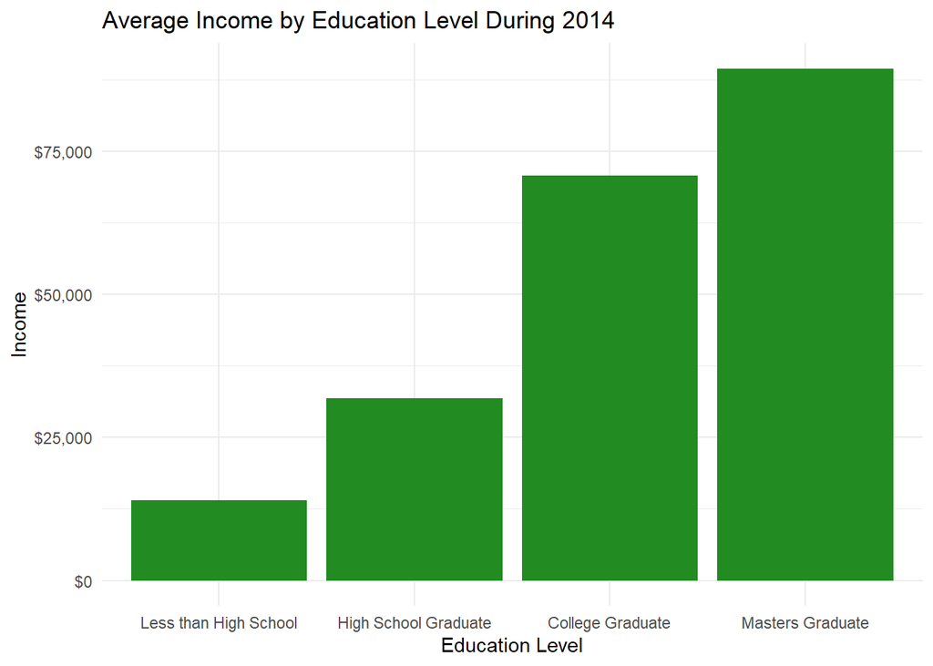

```r
ggplot(data = na.omit(edu_income_average), aes(x = education_level, y = average_income)) +
  geom_col(fill = "forestgreen") +
  labs(title = "Average Income by Education Level During 2014", x = "Education Level", y = "Income") +
  theme_minimal() +
  scale_y_continuous(labels = scales::dollar)
```

The bar graph shows that individuals with higher levels of education tend to earn more on average, for example, people with a college degree or a master’s degree are expected to have taller bars (higher average income) compared to those with only a high school education or less

There is a substantial jump in income from “High School Graduate” to “College Graduate”

The bar graph ultimately shows that higher education levels correlate with higher average incomes in 2014, it shows the economic advantage of attaining higher educational degrees, with the tallest bars representing the highest average income for those with advanced degrees

## **Visualizing Average Income by Education Level (Excluding Outliers)**

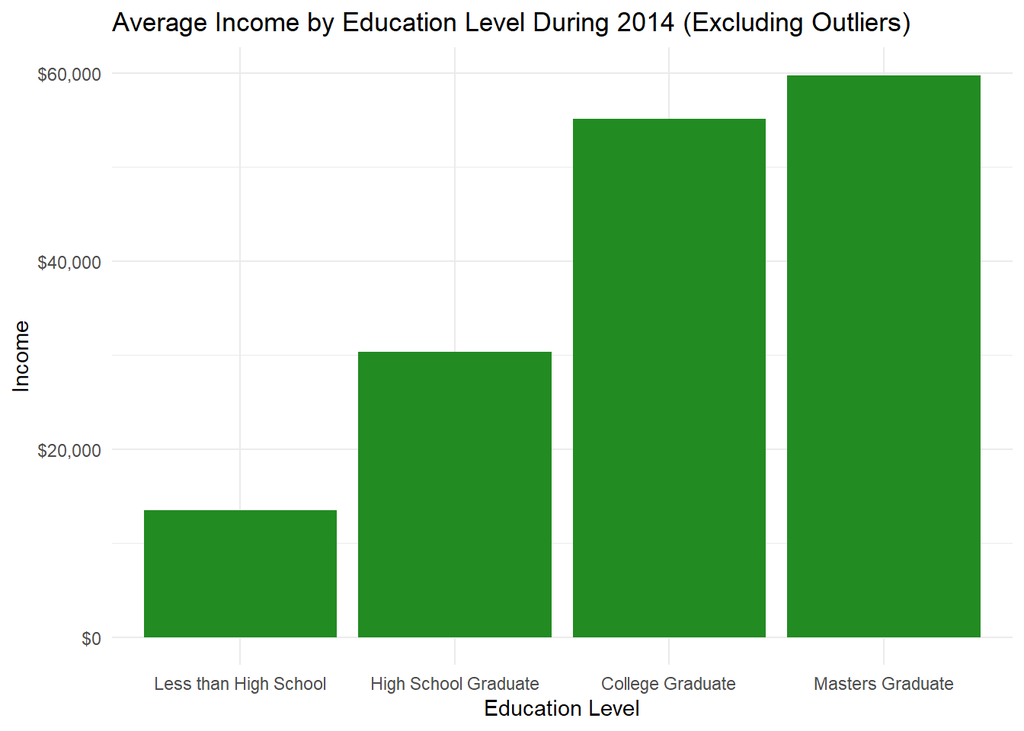

```r
ggplot(data = na.omit(less_high_income2), aes(x = education_level, y = average_income)) +
  geom_col(fill = "forestgreen") +
  labs(title = "Average Income by Education Level During 2014 (Excluding Outliers)", x = "Education Level", y = "Income") +
  scale_y_continuous(labels = scales::dollar) +
  theme_minimal()
```

The bar graph still shows that individuals with higher levels of education tend to earn more on average, for example, people with a college degree or a master’s degree are expected to have taller bars (higher average income) compared to those with only a high school education or less.

There is a substantial jump in income from “High School Graduate” to “College Graduate.”

The bar graph ultimately shows that higher education levels correlate with higher average incomes in 2014, with the tallest bars representing the highest average income for those with advanced degrees.

## **Visualizing Distribution of Income by Education Level**

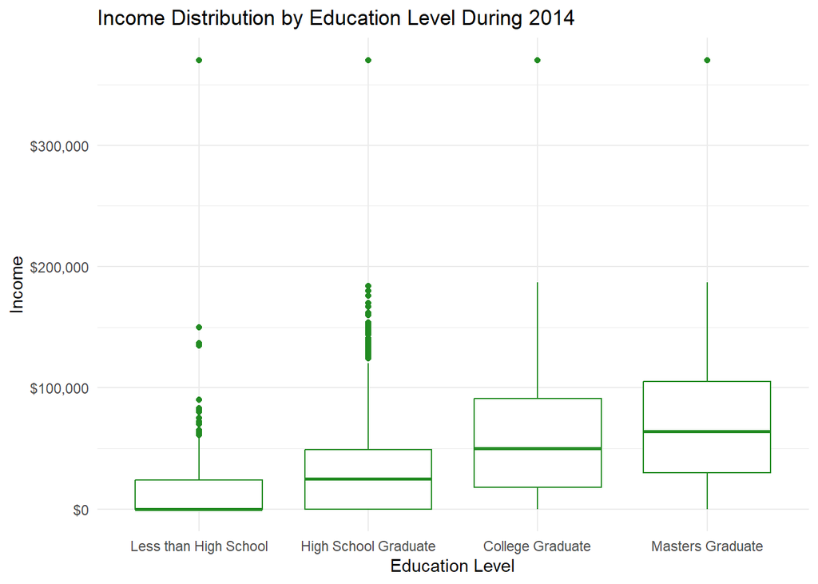

```r
ggplot(data = na.omit(edu_phys_income_2014), aes(x = education_level, y = income)) +
  geom_boxplot(color = "forestgreen") +
  labs(title = "Income Distribution by Education Level During 2014", x = "Education Level", y = "Income") +
  theme_minimal()+
  scale_y_continuous(labels = scales::dollar)
```

The box plot shows that individuals with higher education levels have higher median incomes than those with lower education levels.

The box and whiskers show a wider range of distributions because of the very high income values at the top of the graph, regardless of education level, the highest income that an individual had in the data was $370,314.

There is some degree of income inequality because the box and whiskers for College Graduates and Masters Graduates are wider compared to the box and whiskers for High School Graduates and lower education levels.

## **Visualizing Distribution of Income by Education Level (Excluding Outliers)**

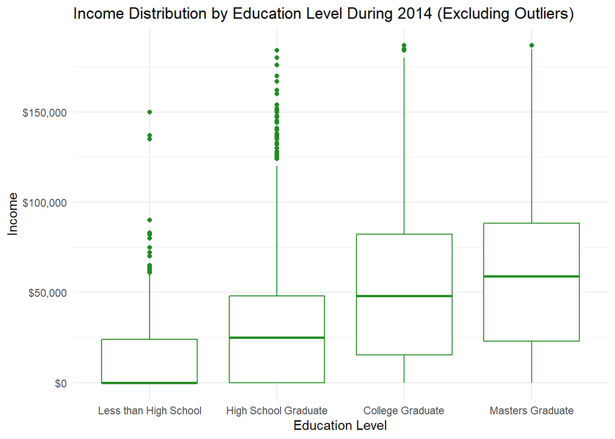

```r
ggplot(data = na.omit(less_high_income), aes(x = education_level, y = income)) +
  geom_boxplot(color = "forestgreen") +
  labs(title = "Income Distribution by Education Level During 2014 (Excluding Outliers)", x = "Education Level", y = "Income") +
  scale_y_continuous(labels = scales::dollar) +
  theme_minimal()
```

The box plot still shows that individuals with higher education levels have higher median incomes than those with lower education levels.

The box and whiskers still show a wide range of distributions, but a smaller range compared to the box and whiskers with the extreme values of $370,314.

There is still some degree of income inequality because the box and whiskers for College Graduates and Masters Graduates are wider compared to the box and whiskers for High School Graduates and lower education levels.

## **Summarizing the Count, Proportion, Average Income, and Median Income by Education Level**

```r
summary_edu_income <- edu_phys_income_2014 %>%
  group_by(education_level) %>%
  summarise(
    Count = n(),
    Proportion = Count / nrow(edu_phys_income_2014),
    Mean_Income = mean(income),
    Median_Income = median(income),
  )
colnames(summary_edu_income) <- c("Education Level", "Count", "Proportion", "Average Income", "Median Income")
#| echo: false
#| output: true
summary_edu_income
```

| Education Level | Count | Proportion | Average Income | Median Income |
| --- | --- | --- | --- | --- |
| Less than High School | 756 | 0.1114551 | 13955.58 | 0 |
| High School Graduate | 4190 | 0.6177208 | 31804.29 | 25000 |
| College Graduate | 1094 | 0.1612856 | 70702.69 | 50000 |
| Masters Graduate | 743 | 0.1095386 | 89448.81 | 63000 |

The majority of people in the edu_phys_income_2014 data set are high school graduates, with a count of 4,190 people with this education level, making up 62% of the proportion of individuals in the data set.

Masters Graduates have the highest average income in the data set, with an average income of $89,448

Masters Graduates also have the highest median income in the data set, with a median income of $63,000.

The summary table ultimately shows that higher education levels correlate with higher average incomes in 2014.

## **Summarizing the Count, Proportion, Average Income, and Median Income by Education Level (Excluding Outliers)**

```r
summary_edu_income2 <- less_high_income %>%
  group_by(education_level) %>%
  summarise(
    Count = n(),
    Proportion = Count / nrow(less_high_income),
    Mean_Income = mean(income),
    Median_Income = median(income),
  )
colnames(summary_edu_income2) <- c("Education Level", "Count", "Proportion", "Average Income", "Median Income")
#| echo: false
#| output: true
summary_edu_income2
```

| Education Level | Count | Proportion | Average Income | Median Income |
| --- | --- | --- | --- | --- |
| Less than High School | 755 | 0.1137219 | 13483.58 | 0 |
| High School Graduate | 4172 | 0.6284079 | 30343.80 | 25000 |
| College Graduate | 1040 | 0.1566501 | 55145.95 | 48000 |
| Masters Graduate | 672 | 0.1012201 | 59774.07 | 59000 |

Excluding the extreme values, the majority of people in the edu_phys_income_2014 data set are still high school graduates, with a count of 4,172 people with this education level, making up 63% of the proportion of individuals in the data set.

Masters Graduates have the highest average income in the data set, with an average income of $59,774.

Masters Graduates also have the highest median income in the data set, with a median income of $59,000.

While excluding the extreme values, the summary table still ultimately shows that higher education levels correlate with higher average incomes in 2014.

# **Exploring the Affects of Gender on Income During 2014**

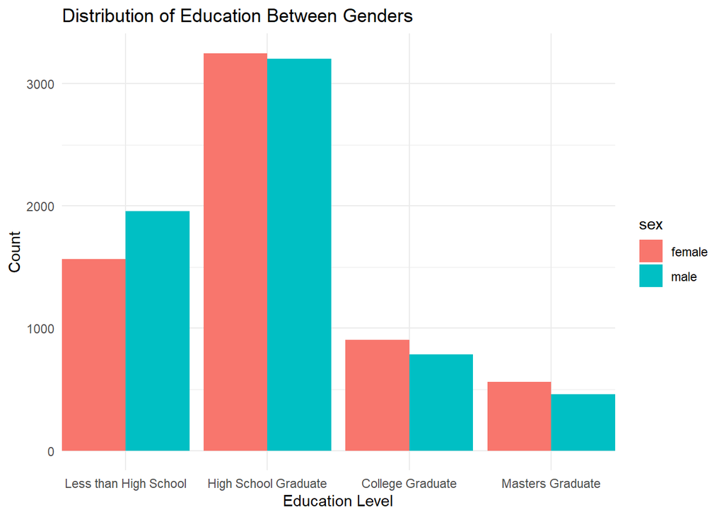

```r
ggplot(data = edu_phys, aes(x = education_level, fill = sex)) +
  geom_bar(position = "dodge") +
  scale_x_discrete(
    expand = expansion(mult = c(0.1, 0.1))
  ) +
  theme_minimal() +
  labs(title = "Distribution of Education Between Genders", x = "Education Level", y = "Count")
```

Running the table above we can see the distribution of education levels between our male and female population. We can see that females have a slight edge over our male population as the education levels increase.

Unsurprisingly, the majority of our population only have a high school education with the lowest population having a masters degree.

## **Visualizing Income between Genders**

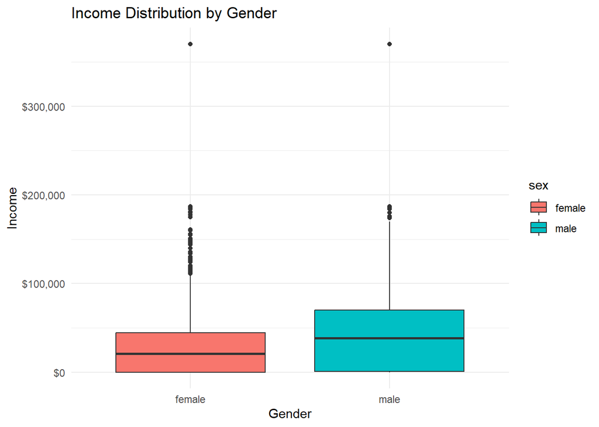

```r
ggplot(data = edu_phys_income_2014, aes(x = sex, y = income)) +
  geom_boxplot(aes(fill = sex)) +
  labs(title = "Income Distribution by Gender",
       x = "Gender",
       y = "Income") +
  scale_y_continuous(labels = scales::dollar) +
  theme_minimal()
```

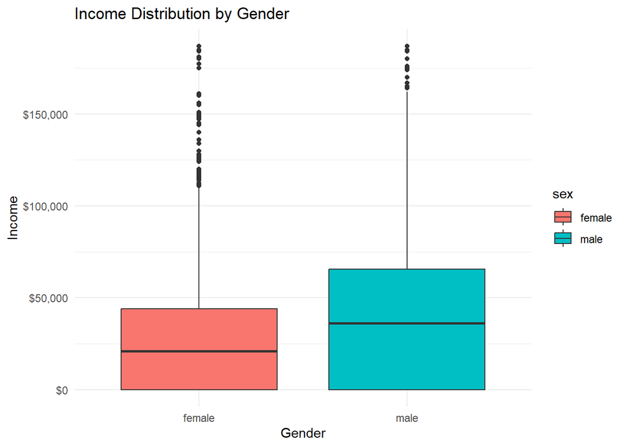

```r
ggplot(data = less_high_income, aes(x = sex, y = income)) +
  geom_boxplot(aes(fill = sex)) +
  labs(title = "Income Distribution by Gender",
       x = "Gender",
       y = "Income")+
  scale_y_continuous(labels = scales::dollar) +
  theme_minimal()
```

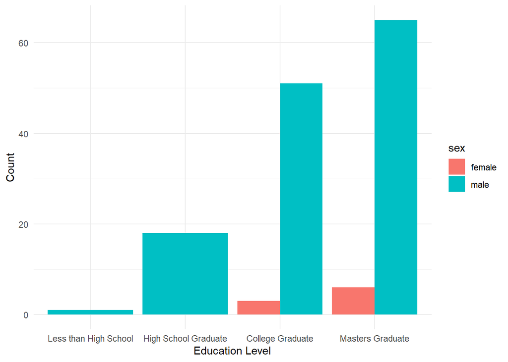

```r
ggplot(data = max_income, aes(x = education_level, fill = sex)) +
  geom_bar(position = "dodge") +
  theme_minimal() +
  labs(x = "Education Level", y = "Count")
```

```r
less_high_income |>
  group_by(sex) |>
       summarise(mean_less_high_income = mean(income, na.rm = TRUE))
```

| sex | mean_less_high_income |
| --- | --- |
| female | 28579.00 |
| male | 42760.55 |

# **Exploring the Affects of Race on Income During 2014**

```r
income_data_2014 <- income_data_nlsy79 |>
  inner_join(physical_data_nlsy79, by = join_by(CASEID, year)) |>
  filter(year == 2014) |>
  mutate(income = ifelse(income > 500000, NA, income)) |>
  filter(!is.na(income) & income > 0) |>
  group_by(CASEID) |>
  mutate(max_income = max(income)) |>
  ungroup() |>
  mutate(income_level = case_when(
    max_income >= 100000 ~ "High Income",
    max_income >= 50000 ~ "Medium Income",
    max_income >= 25000 ~ "Low Income",
    max_income < 25000 ~ "Very Low Income"
  )) |>
  mutate(income_level = factor(income_level,
                               levels = c("Very Low Income",
                                          "Low Income",
                                          "Medium Income",
                                          "High Income")))
print(income_data_2014)
```

```
# A tibble: 4,934 × 12
   CASEID income  year weight eyes  hair     race  sex   height   BMI max_income
    <int>  <int> <int>  <int> <chr> <chr>    <chr> <chr>  <int> <dbl>      <int>
 1      2  21000  2014    151 hazel light b… NBNH  fema…     60  29.5      21000
 2      3  40000  2014    160 blue  blond    NBNH  fema…     70  23.0      40000
 3      6 112000  2014    195 brown brown    NBNH  male      65  32.4     112000
 4      8  47000  2014    192 hazel brown    NBNH  fema…     63  34.0      47000
 5      9  80000  2014    190 hazel brown    NBNH  male      66  30.7      80000
 6     14  45000  2014    195 blue  blond    NBNH  fema…     67  30.5      45000
 7     16  74000  2014    170 brown brown    NBNH  fema…     64  29.2      74000
 8     17  68000  2014    172 hazel brown    NBNH  male      69  25.4      68000
 9     18 151000  2014    190 green brown    NBNH  male      69  28.1     151000
10     20 112000  2014    142 brown brown    NBNH  fema…     64  24.4     112000
# ℹ 4,924 more rows
# ℹ 1 more variable: income_level <fct>
```

# **Exploring the incomes of people during the year of 2014**

This summary of the income tells us there’s a wide range between the minimum (1) and maximum (370314) values. The mean (58293) is higher than the median (42000), suggesting a right-skewed distribution, likely due to some very high values.50% of the data falls between 23391 (1st quartile) and 70000 (3rd quartile).

```r
income_summary = summary(income_data_2014$income)

print(income_summary)
```

```
   Min. 1st Qu.  Median    Mean 3rd Qu.    Max.
      1   23391   42000   58293   70000  370314
```

```r
income_data_2014 <- income_data_2014 |>
  mutate(income_level = case_when(
    income >= 100000 ~ "High Income",
    income >= 50000 ~ "Medium Income",
    income >= 25000 ~ "Low Income",
    income < 25000 ~ "Very Low Income"
  )) |>
  mutate(income_level = factor(income_level,
                               levels = c("Very Low Income",
                                          "Low Income",
                                          "Medium Income",
                                          "High Income")))

income_distribution <- table(income_data_2014$income_level)
print(income_distribution)
```

```
Very Low Income      Low Income   Medium Income     High Income
           1303            1538            1455             638
```

## **Distribution of income in 2014**

This histogram shows how income is distributed in 2014.Most of the population has lower income: The highest number of people (around 600–700) earn between $0 and $50,000.There’s a steep decline: As income increases, the number of people earning more decreases sharply, especially after the $100,000 mark.A notable outlier or gap around $400,000: There’s a small, distinct spike near $400,000, indicating a group with much higher incomes than the rest.

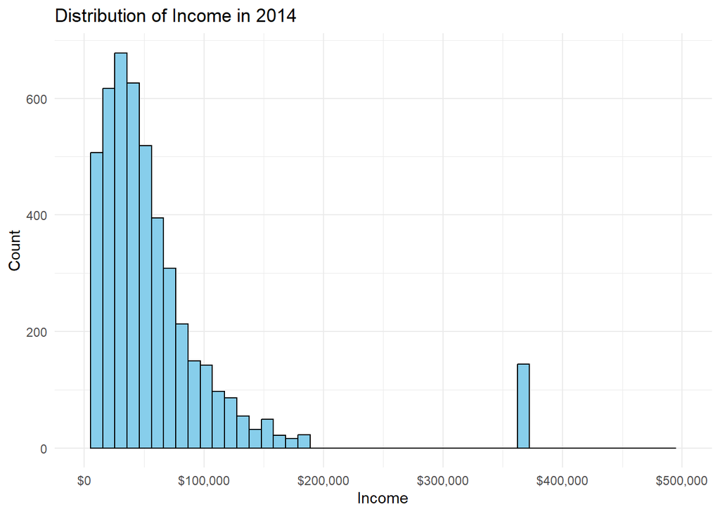

```r
p <- ggplot(income_data_2014, aes(x = income)) +
  geom_histogram(bins = 50, fill = "skyblue", color = "black") +
  scale_x_continuous(labels = scales::dollar_format(), limits = c(0, 500000)) +
  labs(title = "Distribution of Income in 2014",
       x = "Income", y = "Count") +
  theme_minimal()

print(p)
```

## **Average income by race**

There is a noticeable income disparity among these racial/ethnic groups. The NBNH group earns, on average, significantly more than both Hispanic and Black groups.The order of average income from highest to lowest is NBNH, Hispanic, and Black.The difference in average income between the highest-earning group (NBNH) and the lowest-earning group (Black) is substantial, at $24,058.61.

```r
avg_income_by_race <- income_data_2014 |>
  group_by(race) |>
  summarise(avg_income = mean(income, na.rm = TRUE)) |>
  arrange(desc(avg_income))

print(avg_income_by_race)
```

```
# A tibble: 3 × 2
  race     avg_income
  <chr>         <dbl>
1 NBNH         68334.
2 hispanic     50707.
3 black        44275.
```

## **Correlation between income and other variables**

This matrix shows the relationships between income, weight, height, and BMI in 2014. The strongest relationship is between weight and BMI, which is expected as BMI is calculated using weight. There’s a moderate positive relationship between weight and height.Income has weak to very weak relationships with the physical characteristics, with the strongest being with height. BMI has a strong positive relationship with weight but very weak relationships with height and income.

```r
cor_matrix <- income_data_2014 |>
  select(income, weight, height, BMI) |>
  cor(use = "complete.obs")

print(cor_matrix)
```

```
            income     weight      height         BMI
income  1.00000000 0.08212939  0.24411450 -0.05499486
weight  0.08212939 1.00000000  0.49813135  0.83085234
height  0.24411450 0.49813135  1.00000000 -0.05394027
BMI    -0.05499486 0.83085234 -0.05394027  1.00000000
```

## **The following question has been constructed to analyze the income data.**

**Q - How big of an impact does race have on the incomes of people during that year?**

1. The data reveals Non-Black Non-Hispanic (NBNH) individuals earning the highest average income at $68,333.92, followed by Hispanics at $50,706.64, and Black individuals at $44,275.31.
2. The median income figures show NBNH individuals having a median income of $48,000, compared to $40,000 for Hispanics and $35,000 for Black individuals. This indicates that the income gap persists even when considering the middle point of each group’s income distribution.
3. These substantial differences in both average and median incomes across racial groups suggest that race has a considerable impact on income levels, with NBNH individuals earning on average about 54% more than Black individuals and about 35% more than Hispanic individuals during 2014

   ```r
   income_summary <- income_data_2014 |>
     group_by(race) |>
     summarize(avg_income = mean(income, na.rm = TRUE)) |>
     arrange(desc(avg_income))

   income_race_data_2014 <- income_data_nlsy79 |>
     inner_join(physical_data_nlsy79, by = c("CASEID", "year")) |>
     filter(year == 2014) |>
     filter(!is.na(income) & income > 0) |>
     filter(!is.na(race))

   avg_income_by_race_2014 <- income_race_data_2014 |>
     group_by(race) |>
     summarise(
       avg_income = mean(income, na.rm = TRUE),
       median_income = median(income, na.rm = TRUE),
       count = n()
     ) |>
     arrange(desc(avg_income))

   print(avg_income_by_race_2014)
   ```

   ```
   # A tibble: 3 × 4
     race     avg_income median_income count
     <chr>         <dbl>         <dbl> <int>
   1 NBNH         68334.         48000  2630
   2 hispanic     50707.         40000   916
   3 black        44275.         35000  1388
   ```

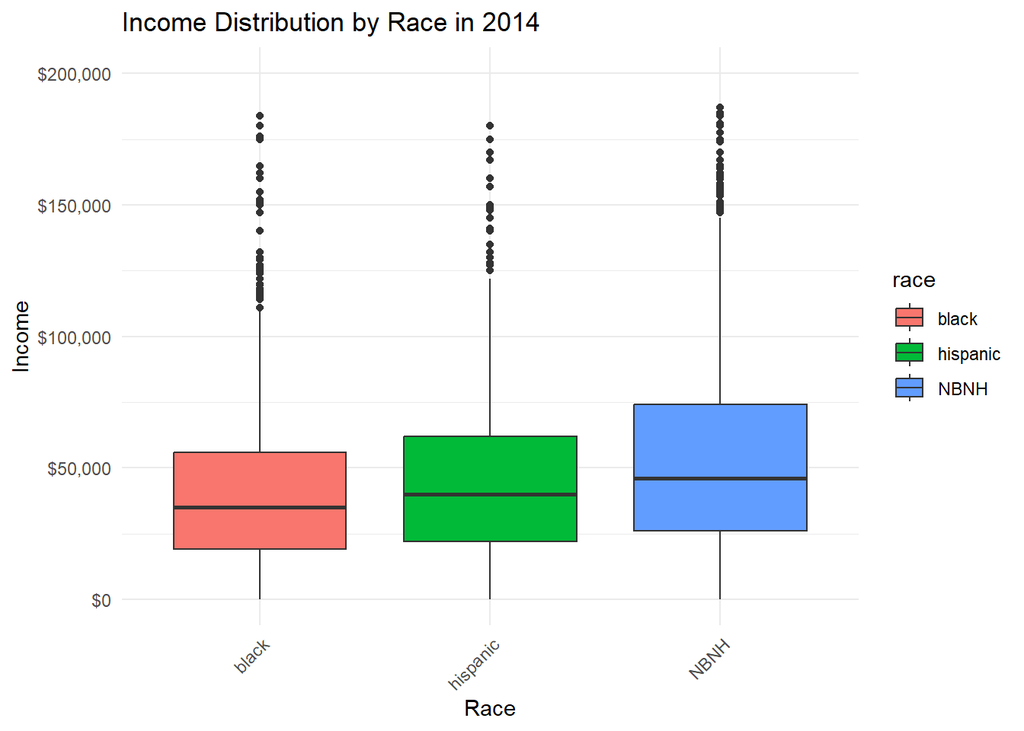

   ```r
   ggplot(income_race_data_2014, aes(x = race, y = income, fill = race)) +
         geom_boxplot() +
         scale_y_continuous(labels = scales::dollar_format(), limits = c(0, 200000)) +
         labs(title = "Income Distribution by Race in 2014",
              x = "Race", y = "Income") +
     theme_minimal() +
         theme(axis.text.x = element_text(angle = 45, hjust = 1))
   ```

## **Summary of Income and Education Analysis**

## **Education and Income**

- **Bar Graphs**: Individuals with higher education levels, such as college or master’s degrees, tend to earn more. There’s a noticeable income increase from high school to college graduates.
- **Box Plots**: Higher education levels correlate with higher median incomes. The income range is wider for those with advanced degrees, indicating income inequality.

## **Race and Income**

- **Income Distribution**: Non-Black Non-Hispanic (NBNH) individuals earn significantly more on average than Hispanic and Black individuals. The income gap is substantial, with NBNH individuals earning about 54% more than Black individuals.
- **Median Income**: Reflects similar disparities, with NBNH individuals having the highest median income.

## **Correlations**

- **Income vs. Physical Characteristics**: Weak correlations between income and physical characteristics like height and BMI. The strongest relationship is between weight and BMI.

## **Conclusion**

The analysis reveals significant disparities in income based on education, gender, and race. Higher education levels generally lead to higher incomes, while gender and race also play substantial roles in determining economic outcomes. Educational attainment appears to be a key factor influencing these disparities.